# Lab 06: Simulation-based inference

due Monday, October 18 at 11:59pm

# Learning Goals

In this lab you will…

- Learn how to identify and handle merge conflicts
- Use simulation-based inference to draw conclusions about population parameters

# Getting started

- A repository has already been created for you and your teammates. Everyone in your team has access to the same repo.
- Go to the sta199-fa21-003 course organization on GitHub.
- You should see a repo with the *lab-06** prefix.
- Each person on the team should clone the repository and open a new project in RStudio. Do not make any changes to the .Rmd file until the instructions tell you do to so.

# Merge Conflicts (uh oh)

[figure not shown]

You may have seen this already through the course of your collaboration in the past few weeks. When two collaborators make changes to a file and push the file to their repository, git merges these two files.

[figure not shown]

If these two files have conflicting content on the same line, git will produce a **merge conflict**. Merge conflicts need to be resolved manually, as they require a human intervention:

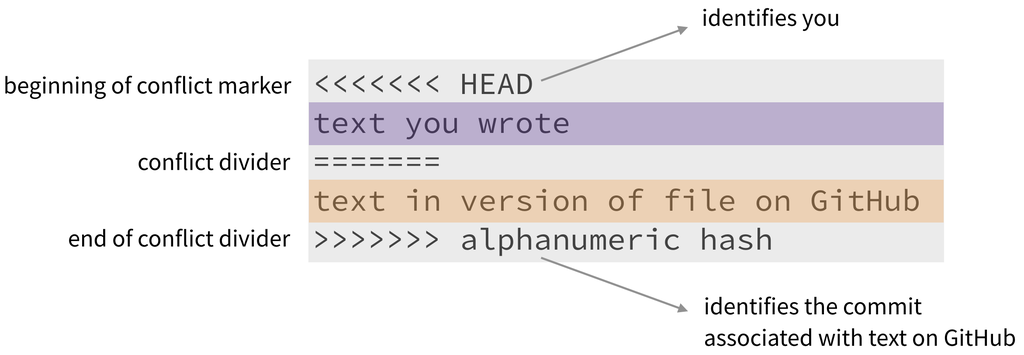

To resolve the merge conflict, decide if you want to keep only your text, the text on GitHub, or incorporate changes from both texts. Delete the conflict markers `<<<<<<<`, `=======`, `>>>>>>>` and make the changes you want in the final merge.

**Assign numbers 1, 2, 3, and 4 to each of your team members** (if only 3 team members, just number 1 through 3). Go through the following steps in detail, which simulate a merge conflict. Completing this exercise will be part of the lab grade.

## Resolving a merge conflict

**Step 1: Everyone** Clone the repo with the prefix **merge-conflict** and open the .Rmd file.

**Team Member 4** should look at the group’s repo on GitHub.com to ensure that the other members’ files are pushed to GitHub after every step.

**Step 2: Team Member 1** Change the team name to your team name. *Knit, commit, and push*.

**Step 3: Member 2** Change the team name to something different (i.e., not your team name). *Knit, commit, and push*.

You should get an error.

**Pull** and review the document with the merge conflict. Read the error to your teammates. You can also show them the error by sharing your screen. A merge conflict occurred because you edited the same part of the document as Member 1. Resolve the conflict with whichever name you want to keep, then knit, commit and push again.

**Step 4: Member 3** Write some narrative in the space provided. You should get an error.

This time, no merge conflicts should occur, since you edited a different part of the document from Members 1 and 2. Read the error to your teammates. You can also show them the error by sharing your screen.

Click to pull. *Then, knit, commit, and push.* All merge conflicts should be resolved and all documents updated in the GitHub repo.

You do not need to submit anything on Gradescope for the merge conflict activity.

## Workflow: Using git and GitHub as a team

The following exercises must be done in order. Only one person should type in the .Rmd file and push updates at a time. When it is not your turn to type, you should still share ideas and contribute to the team’s discussion.

## Packages

We will use the **tidyverse** and **tidymodels** packages in this lab.

```r
library(tidyverse)
library(tidymodels)
```

# Data: Durham Resident Satisfaction Survey

Today’s data comes from the City of Durham’s annual Resident Satisfaction Survey for 2020. [Click here](https://www.dconc.gov/home/showpublisheddocument/33786/637477764750700000) to read the full report of results from the survey. In particular, `durham-survey-2020.csv` contains data from over 800 Durham residents on a variety of questions about their experience living in the city. Assume that the data are representative of Durham residents and may be generalized to the wider population of all city residents.

The following variables are used in this analysis:

- `age`: Age category
  - 1: 18 - 34 years old
  - 2: 35 - 44 years old
  - 3: 45 - 54 years old
  - 4: 55 - 64 years old
  - 5: 65+ years old
  - 9: Age not provided
- `length_in_durham`: How long respondent has lived in Durham (in years)
- `mask_public_outdoor`: How often respondent reported wearing a mask in an public outdoor gathering
  - 1: Never
  - 2: Rarely
  - 3: Sometimes
  - 4: Frequently
  - 5: Always
  - 9: No response provided
- `condition_public_art`: How respondent rated their satisfaction with the condition of public art in Durham (1: lowest - 5: highest, 9: no response provided)

Fill in the code to load the data set.

```r
____ <- read_csv("_______")
```

# Exercises

## Instructions

- Use a small number of reps (about 100) as you write and test out your code. Once you have finalized all of your code, increase the number of reps to 10,000 to produce your final results.
- Write your code and narrative in a reproducible way, so you can easily change the number of reps. For example, consider ways you can write your narrative using inline code, so the relevant values update when you change the number of reps.
- For each exercise, filter out observations that have values corresponding to “no response” for the variable of interest in that exercise.
- For each simulation exercise, use the seed specified in the exercise instructions.
- All narrative should be written in full sentences, and visualizations should have clear title and axis labels.

**Hint**: be careful with how missing values are coded in this survey. As well, don’t forget to set the seed specified in the instructions in order to ensure reproducibility!

1. We’ll begin by analyzing the typical number of years current residents have lived in Durham.
   - Visualize the distribution of the number of years respondents have lived in Durham.
   - Is the mean or median more representative of the typical number of years current residents have lived in Durham? Briefly explain.
   - Calculate the point estimate for the typical number of years current residents have lived in Durham.
2. Calculate a 95% bootstrap confidence interval for the typical number of years current residents have lived in Durham. The confidence interval should be calculated for the parameter (mean or median) you chose in Exercise 1. Use `set.seed(2)`.

   Then, then interpret the interval in the context of the data.
3. Next, let’s look at how frequently Durham residents wore masks at public outdoor events in 2020.

   **Hint:** You will need to make a new variable.
   - Calculate the proportion of survey respondents who wore a mask frequently (`4`) or always (`5`) at public outdoor events, among those who provided a response to this question.
   - Calcualte a 98% bootstrap confidence interval for the proportion of Durham residents who wore a mask frequently or always at public outdoor events in 2020. Use `set.seed(3)`.
   - Interpret the confidence interval in the context of the data.
4. According to data from the [United States Census](https://www.census.gov/data/tables/2019/demo/age-and-sex/2019-age-sex-composition.html), 46% of US adults are 18 - 44 years old. Is the proportion of adults in Durham who are 18 - 44 years different from the proportion of adults in this age range in the United States?
   - Create a new variable indicating if a survey respondent is 18 - 44 years old.
   - Calculate the proportion of survey respondents who are 18-44 years old, among those who provided an age.
5. Conduct a hypothesis test to test the question stated in Exercise 4.
   - State the null and alternative hypotheses in both words and mathematical notation.
   - Construct the null distribution using `set.seed(5)`. Then visualize the distribution and the shaded region corresponding to the p-value.
   - Calculate the p-value.
   - State your conclusion in the context of the data, using a significance level of 0.05.
6. Are Durham residents generally satisfied with the condition of public art in the city? We’ll considered “generally satisfied” as having a mean satisfaction score greater than 3.
   - State the null and alternative hypotheses in both words and mathematical notation.
   - Construct the null distribution. Use `set.seed(6)`. Then visualize the distribution and the shaded region corresponding to the p-value.
   - Calculate the p-value.
   - State your conclusion in the context of the data, using a significance level of 0.05.
7. Given your conclusion in Exercise 6, which type of error could you possibly have made? What would making such an error mean in the context of the analysis question?

# Wrapping up

Go back through your write up to make sure you followed the coding style guidelines we discussed in class (e.g. no long lines of code).

# Submission

- **Select** one team member to upload the team’s PDF submission to Gradescope.
- Be sure to select every team member’s name in the Gradescope.
- Associate the “Workflow & formatting” graded section with the first page of your PDF, and mark the page associated with each exercise. If any answer spans multiple pages, then mark all pages.

**There should only be** one submission per team on Gradescope.

# Grading (50 pts)

| Component | Points |
| --- | --- |
| Ex 1 | 6 |
| Ex 2 | 6 |
| Ex 3 | 8 |
| Ex 4 | 4 |
| Ex 5 | 6 |
| Ex 6 | 6 |
| Ex 7 | 5 |
| Merge conflict activity | 4 |
| Workflow & formatting | 5 |

- The “Workflow & formatting” grade is to assess the reproducible workflow. This includes having at least one informative commit by each team member, labeling the code chunks, and having readable code in the tidyverse syntax that does not exceed 80 characters (i.e., we can read all your code in the knitted PDF.)